# US–China Competition

POLISCI 158 · AI & Politics · Session 14 · Monday, November 9, 2026

Simone Paci

## Roadmap

1. Part I: Why a race?
   - Security dilemma -> why states frame AI as a race
   - Two prizes: first to AGI vs diffusion marathon
2. Part II: Who’s winning?
   - Scoreboard: where US leads, where China leads
   - Winner depends on which race
3. Part III: The chokepoint and its leaks
   - Compute as chokepoint -> how export controls leak
   - China’s counter-chokepoints

## What do Americans think?

[figure not shown]

Ahead at what?

33% not sure

Pew Research Center, survey June 22–28, 2026 (n = 3,488)

## Does keeping up with China matter to Americans?

69% keeping up w/ China in AI = important very 40 · somewhat 29

81% safety > staying at forefront of innovation innovation: 14

65% hold both views

2 separate questions · safety item doesn’t mention China

Quinnipiac University Poll, Sep 24–27, 2026 (n = 1,202, ±3.5)

# Part I: Why would states race over AI?

Last week the compute had an address. This week it has a flag.

## Why did one Chinese model move markets?

−17% ≈$593B one day

DeepSeek-R1 out: Jan 20, 2025

Mon, Jan 27: Nvidia −17% in 1 day, ~$593B market value

“DeepSeek-R1 is AI’s Sputnik moment.” Marc Andreessen (VC)

$589–600B, by data vendor

DeepSeek release note, Jan 20, 2025; Reuters/LSEG, Jan 28, 2025; Fortune, Jan 27, 2025

## At what level should we look?

Waltz: 3 images of the causes of war

[figure not shown]

Waltz, *Man, the State, and War* (1959; Columbia UP, 2018 ed.)

## Why does one side’s defense look like a threat?

“Many of the means by which a state tries to increase its security decrease the security of others.” Jervis (1978)

Jervis (1978), *World Politics*, p. 169, as quoted in Scharre (2021)

## Zero-sum or positive-sum?

| Realism | Liberalism |
| --- | --- |
| Relative gains: your gain = my loss | Absolute gains: both can gain |
| Security first · balance of power | Trade, research, institutions, interdependence |

Which does AI look like?

## What if the “race” is itself an idea?

Constructivism: race framing -> state behavior

What counts as threat -> depends on regime

“…not only Chinese anxiety over losing ground … but also concerns about threats to ideological and regime security.” Zeng (2025), abstract, on China’s reaction to ChatGPT

Zeng: security dilemma · constructivist reading = ours

Zeng, *British Journal of Politics and International Relations*, Nov 5, 2025

## Is it really an arms race?

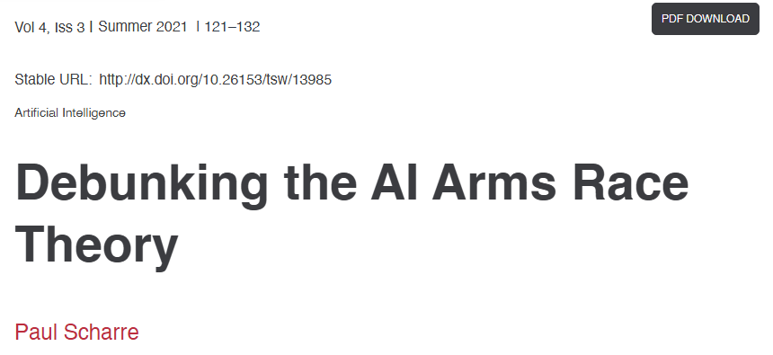

“There is no AI arms race.”

But belief in one -> “cut corners on testing” -> “unsafe AI systems”

2021 · military AI · pre-ChatGPT

Scharre, *Texas National Security Review*, Summer 2021

## What if the first to arrive wins?

[figure not shown]

“The United States is in a race to achieve global dominance in artificial intelligence.” AI Action Plan, July 2025

“Superintelligence will give a decisive economic and military advantage.” Aschenbrenner, 2024

“A temporary lead could be parlayed into a durable advantage.” Dario Amodei (Anthropic CEO), Jan 2025

Aschenbrenner: self-published · Amodei: AI CEO, stake in chip policy

White House, Jul 2025; Aschenbrenner, *Situational Awareness*, Jun 2024; Amodei, “On DeepSeek and Export Controls,” Jan 2025

## Or is it a marathon?

Power = spreading a general-purpose tech across the economy

- “an AI diffusion marathon” vs sprint to AGI (Ding 2025)
- “Diffusion occurs over decades, not years.” (Narayanan and Kapoor 2025)

N&K: generalize from past tech · institute essay, not peer-reviewed

Ding, RAND, Sep 30, 2025, and *Technology and the Rise of Great Powers* (2024); Narayanan and Kapoor, Knight Institute, Apr 2025

## Do leads last?

| Leads leak | Complexity protects leaders |
| --- | --- |
| “AI knowledge is leaky.” “There is no finish line.” (Arbel and Tokson 2026) | Complexity -> weapons hard to imitate, even w/ stolen designs: China vs US stealth fighters (Gilli and Gilli 2019) |

Frontier AI: paper or stealth fighter?

Gilli & Gilli: weapons, not AI · Arbel & Tokson: EUV + stealth leads lasted decades

Arbel and Tokson, *Lawfare*, May 19, 2026; Gilli and Gilli, *International Security*, 2019

## Is the race itself the danger?

| Racing causes risk | A lead makes safety affordable |
| --- | --- |
| Racing -> “skimping on safety precautions” (Armstrong, Bostrom and Shulman 2016) | “Maintaining a healthy lead will be decisive for safety” (Aschenbrenner 2024) |
| Superintelligence race -> great-power conflict, loss of control, weaker liberal democracy (Katzke and Futerman 2024) |  |

Katzke & Futerman, Aschenbrenner: not peer-reviewed

Armstrong et al., *AI & Society*, 2016; Katzke and Futerman, arXiv, Dec 2024; Aschenbrenner, Jun 2024

## Could the threat of sabotage keep the peace?

Mutual Assured AI Malfunction: bid for AI dominance -> “preventive sabotage by rivals”

- Covert cyberattacks -> strikes on datacenters

[figure not shown]

Working paper, not peer-reviewed

Hendrycks, Schmidt and Wang, “Superintelligence Strategy,” arXiv, Mar 2025

# Part II: Who’s winning, and at what?

If the prize differs, so does the scoreboard.

## Who has the compute?

[figure not shown]

New AI compute, H1 2026: 78% -> US

Installed GPU-cluster perf., May 2025: US ~75% · China 15%

Customs-data estimates (arrivals ≠ use) · cluster data ≈ 10–20% of global compute

Epoch AI, Oct 27, 2026 and Jun 5, 2025

## Who has the money?

Private AI investment, 2025

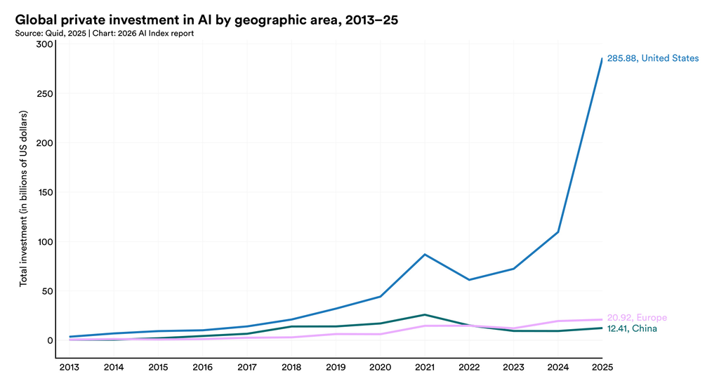

Private investment only; understates China’s state guidance funds.

Stanford HAI, AI Index 2026

## Who builds the best models?

[figure not shown]

Since 2023: every frontier model American · China ~7 mo behind on avg (4–14)

One benchmark composite (Epoch Capabilities Index) · data to Dec 2025

Epoch AI, Jan 2, 2026

## Who makes the chips?

[figure not shown]

Huawei 2026 AI chip output: < 4% of Nvidia’s compute

Huawei chips 3–4 yrs behind Nvidia, until ≥ 2030

Epoch estimates · China’s own advanced lithography: likely after 2030

Epoch AI, Sep 2026

## Which models do users prefer?

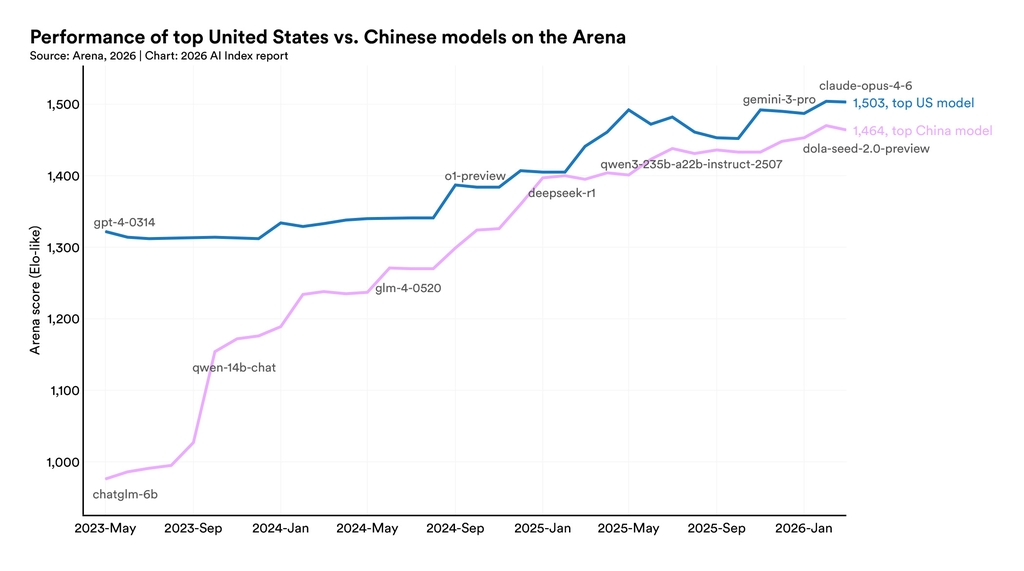

Near parity

- DeepSeek-R1 briefly = top US model (Feb 2025)
- US lead, Mar 2026: 2.7%

Arena = crowd votes on model pairs, not benchmarks · same period as slide 20, different verdict

Stanford HAI, AI Index 2026 (Arena data)

## Whose open models get downloaded?

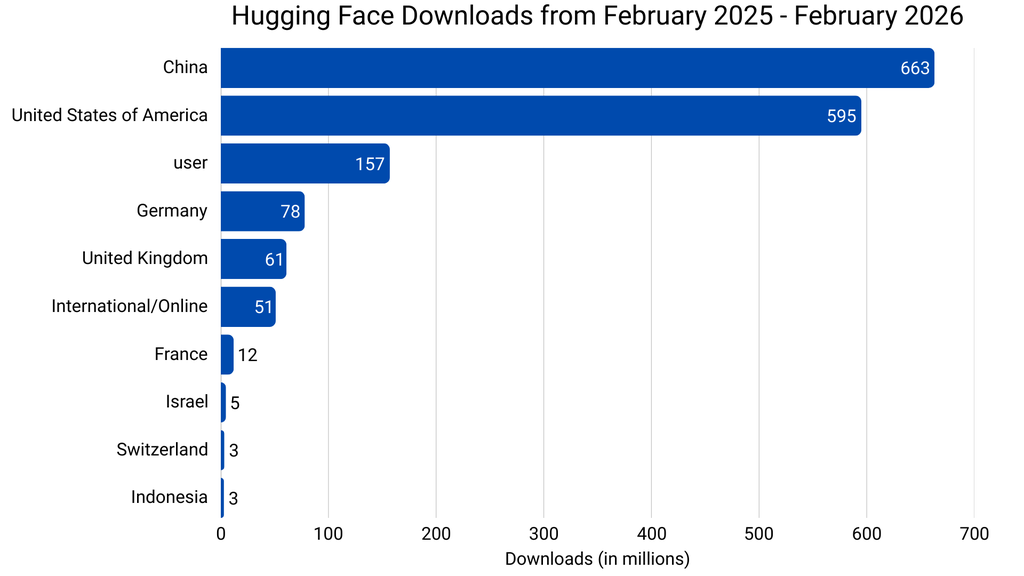

Chinese models: 41% of Hugging Face downloads (Feb 2025–Feb 2026) -> largest share

Qwen, Jan–Jul 2026: ~2.05B downloads · 151,448 derivative models

Misses API + private use · ~half: no clear country · newest large Kimi/Qwen: licence limits

Hugging Face, Mar 17 and Aug 14, 2026

## What does “61%” measure?

Viral claim: Chinese models = “61% of total token consumption on OpenRouter”

- Actually: 61% of top-10 models’ tokens (Ding)
- All models, Nov 2024–Nov 2025: ~13% of weekly tokens on avg, ≈30% some weeks

Top ten only

[figure not shown]

Top-10 leaderboard, week of Mar 1, 2026

All models

[figure not shown]

Token Share by Source Type and Origin, all models, weekly

OpenRouter = small, developer-heavy slice of AI use

Ding, *ChinAI*, Mar 2, 2026; a16z and OpenRouter, “State of AI,” Dec 2025

## Who is automating factories?

China: 59% of world’s new industrial robots, 2025

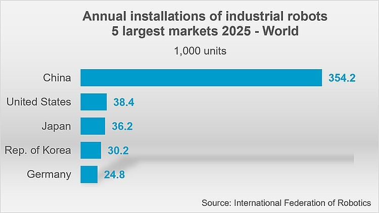

1-year installations, not robot stock

IFR, World Robotics 2026, Sep 24, 2026

## Who builds humanoids, and for what?

Chinese vendors: **over 95%** of **~25,000** humanoids shipped, H1 2026

**69%** -> research/education, display, govt data-collection centres (**83.8%** in 2025)

Trackers disagree on total · 69%: global or China only? IDC doesn’t say

IDC, Sep 29, 2026

## Who is adding the power?

Solar added in 2025: China 378 GW, 58% of the world

Electricity demand growth, 2025: China +5%, US +3%

Solar in GW (DC).

Ember, Global Electricity Review 2026, Apr 21, 2026

## Where is it cheaper to build?

Data center cost/MW: ~$6M China vs ~$10M US

Compute per $: US ahead in both modelled scenarios · H200s close raw-performance gap

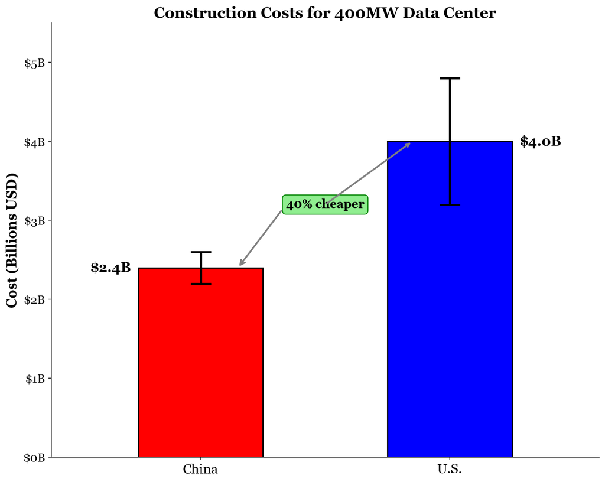

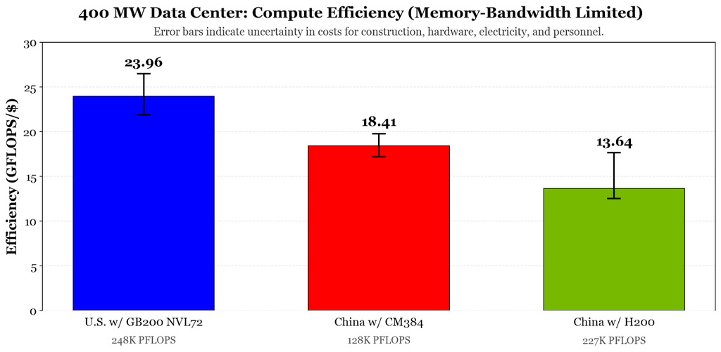

One modelled 400 MW build, single source · hardware prices not public

Zakaria, *ChinaTalk*, Feb 19, 2026

## Who patents more?

GenAI patent families, 2014–2023: China 38,210 vs US 6,276

US leads on higher-impact patents

Quantity ≠ quality · by inventor location

WIPO, Jul 3, 2024; Stanford HAI, AI Index 2026

## Where do the researchers work?

NeurIPS authors by work location, 2022 → 2025: US 46% → 34% · China 27% → 41%

n = 10,280 complete profiles of 25,677

40% subset w/ full career histories, not random · US still net gainer, keeps 89%

Ma and Yang, Carnegie Endowment, Sep 23, 2026

## What is Beijing aiming for?

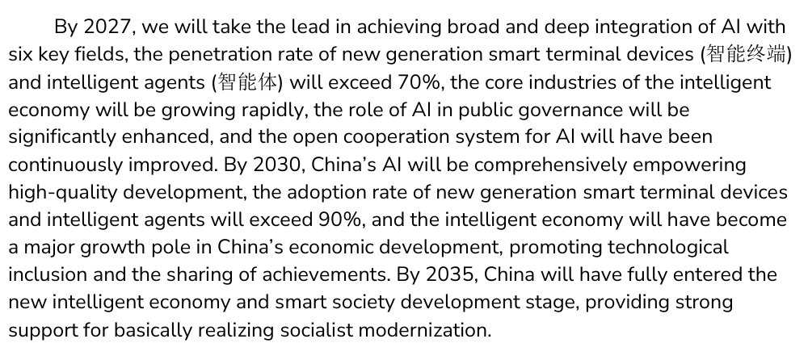

“AI+” plan, Aug 26, 2025

- 2027: > 70% adoption, smart devices + AI agents · 2030: > 90%
- AGI: not mentioned

Also: “enhance the fundamental capabilities of models” · no AGI target

State Council (2025), CSET translation, Sep 24, 2025

## What is Washington aiming for?

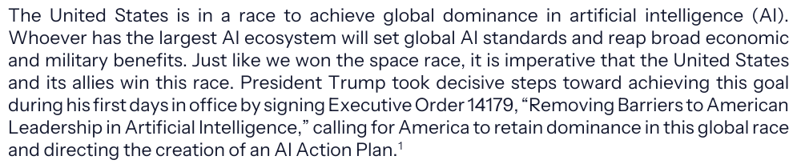

“Just like we won the space race … win this race.” AI Action Plan, July 2025

Sep 29, 2026: executive order renames AI “Super Intelligence” · WH fact sheet: winning “the SI race”

“SI” = new name for AI, existing legal definition, not superintelligence

White House, Jul 2025; Executive Order 14434 and fact sheet, Sep 29, 2026

## What does Xi ask for?

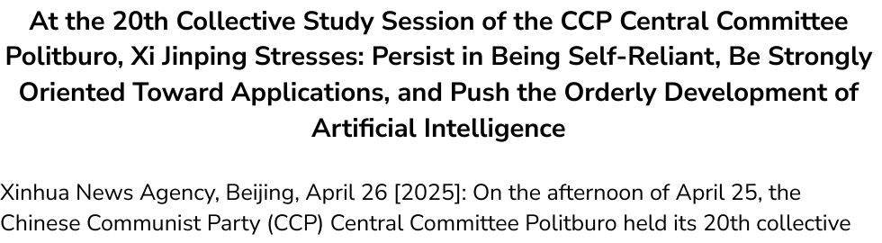

“Persist in Being Self-Reliant, Be Strongly Oriented Toward Applications…” (title of the readout)

- Master “high-end microchips and foundational software”
- Also: “…win superiority in the field of AI”

State-media readout, not transcript · no AGI mention

Xinhua readout of the Politburo study session, Apr 26, 2025; CSET translation

## Is Beijing racing to AGI?

Several analysts: no

“Beijing seems not to care about the so-called ‘race to AGI’.” Kyle Chan

“They aren’t trying to build AGI. They’re trying to make a profit.” Selena Xu

Some founders: yes

“Our destination is AGI.” Liang Wenfeng, DeepSeek

Liang, 2024 interview, as quoted by Chan

Chan, *High Capacity*, Feb 15, 2026; Sheehan and Xu, *Your Undivided Attention*, Dec 18, 2025

## Or is AGI quietly state policy?

“AGI is now written into China’s operating system for modernization.” Matthew Johnson

- Beijing, 2023: general-AI measures -> “explore new paths to general AI”
- Shanghai, 2025: open competition, general-AI tasks, embodied intelligence first
- 15th Five-Year Plan: “exploration of development pathways toward general-purpose AI”

Partly translation: 通用人工智能 = “general-purpose AI” or “AGI”

Johnson, Jamestown *China Brief*, Oct 2025; Beijing municipal government, May 2023; Shanghai SHEITC, Apr 21, 2025; DigiChina, Mar 17, 2026

## Two caveats before we move on

Diffusion strategy ≠ diffusing well

- Ding: judge states by “capacity to diffuse, or widely adopt, innovations”

China’s approach “is partly driven by necessity” -> US controls on Nvidia chips (Chan)

Ding predates AI+ plan · application here = ours

Ding, *Review of International Political Economy*, 2024; Chan, Brookings, Mar 9, 2026

## Debate: does the US–China rivalry stand in the way of slowing down AI?

Assigned sides: left half = yes · right half = no

Can anyone slow down while the other races?

Should the US slow down even if China does not?

Can the US afford to slow down?

1. Pairs · 3 min: build your side’s case from 1+ angles
2. Floor · 8 min: sides alternate, one point at a time
3. Wrap-up · 1 min

Argue assigned side, not own view · written answers welcome

# Part III: Can you stop a rival by cutting off its chips?

The US lever acts on the input where it leads most.

## Where are the chokepoints?

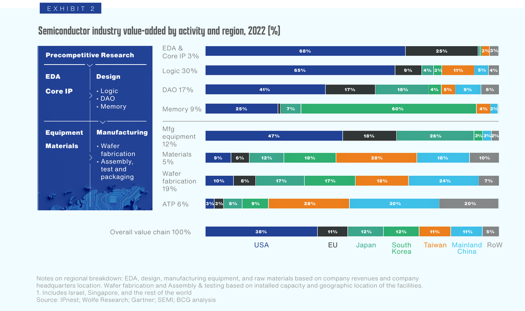

**Design and EDA: US**EDA & core IP: US 68% · logic design: US 65%

**Equipment: US, Japan, EU**US 47% · Japan 26% · EU 18%

**EUV lithography: ASML (Netherlands)**

**Leading-edge fabs: Taiwan, Korea**

**HBM memory: Korea**HBM revenue, Q2 2026: SK hynix 50% · Samsung 33%

Value added by region, 2022 · one European firm: 87% of lithography market

SIA and BCG, May 2024; Counterpoint Research (HBM), Q2 2026

## How does controlling a hub give you power?

Control a central network node

- Panopticon effect: gather info from flows
- Chokepoint effect: deny adversaries access

Cases: SWIFT, internet -> chips?

Farrell and Newman, *International Security*, 2019 (today’s reading)

## How did the US tighten the screws?

Oct 7, 2022

advanced computing and chip-equipment rules

Oct 17, 2023

rules tightened (effective Nov 17)

Dec 2, 2024

high-bandwidth memory, equipment, Entity List additions

Jan 13, 2025

AI Diffusion Rule (published Jan 15)

Bureau of Industry and Security; Federal Register

## Then why loosen them?

Apr 2025

licence required: Nvidia H20

May 13, 2025

Diffusion Rule rescinded

Aug 2025

reported deal: 15% revenue share, H20 sales to China

Jan 2026

H200 licences case by case · cap 50% of US shipments · US testing · 25% import tariff

Blackwell

still presumption of denial

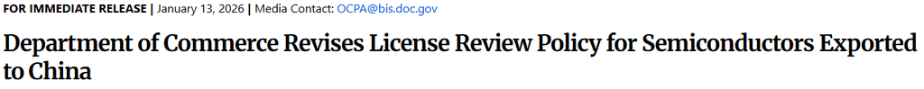

15% deal: reported, never a published rule · 25% = tariff on chips entering US for testing

BIS, May 13, 2025 and Jan 13, 2026; White House fact sheet, Jan 14, 2026; Nvidia filings

## Do the controls work?

US advantage, AI compute produced in 2026

- No exports, no smuggling: 21–49×
- Unrestricted H200 exports: ~1.2× to ~6.7× (volume, supply)

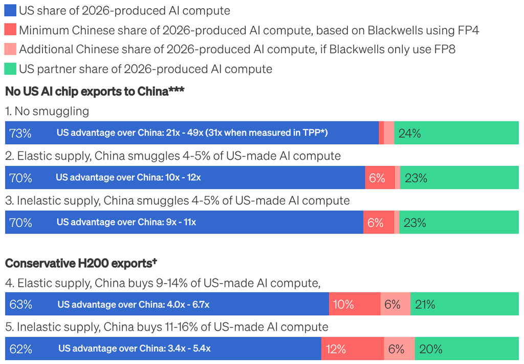

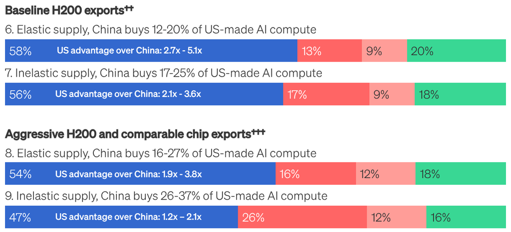

Think-tank model · range depends on export volume + FP4/FP8 assumptions

Institute for Progress (IFP), Dec 7, 2025

## A lead in what?

“a hardware lead of around 4 years when it comes to training frontier models”

“essentially no lead when it comes to serving those models to users”

No peer-reviewed causal estimate found: export controls -> Chinese model capability

Erdil: author’s views · our search (Nov 2026): not systematic

Erdil, Epoch AI *Gradient Updates*, Dec 6, 2024

## Leak 1: how many chips get smuggled?

Est. 290,000–1.6M H100-equivalents smuggled to China through 2025 · median 660,000 ≈ ⅓ of China’s compute

- Operation Gatekeeper (Dec 2025): ≥ $160M of H100s/H200s exported or attempted
- Indictment (Mar 2026): SE Asian buyer, ~$2.5B of US maker’s servers · ≥ $510M allegedly -> China in 1 month

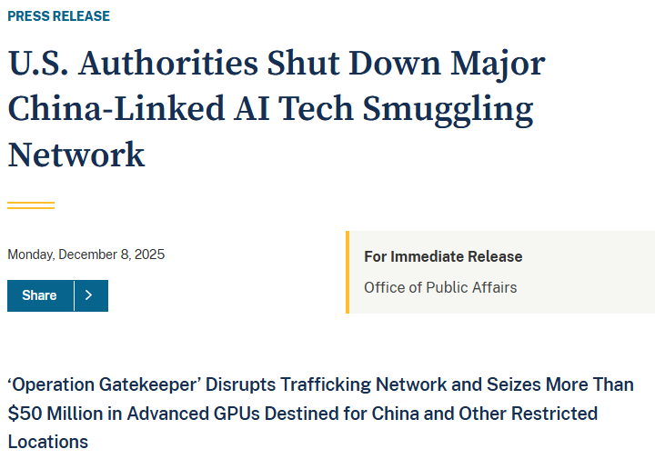

Indictments + complaints = allegations · only Hsu, Hao Global pleaded guilty

Epoch AI, Apr 29, 2026; DOJ, Dec 8, 2025; SDNY, Mar 19, 2026

## Leak 2: why buy chips if you can rent them?

Chinese firms rent Nvidia capacity in SE Asian data centers -> legal under current US law

Remote Access Security Act: passed House -> stuck in Senate committee

Apr 7, 2025

introduced

Apr 9, 2025

committee 51–0

Jan 12, 2026

House 369–22

Jan 13, 2026

referred to Senate Banking

Status as of Nov 7, 2026 · not law

Tan, Carnegie Endowment, May 5, 2026; Congress.gov

## Leak 3: can you copy a model by talking to it?

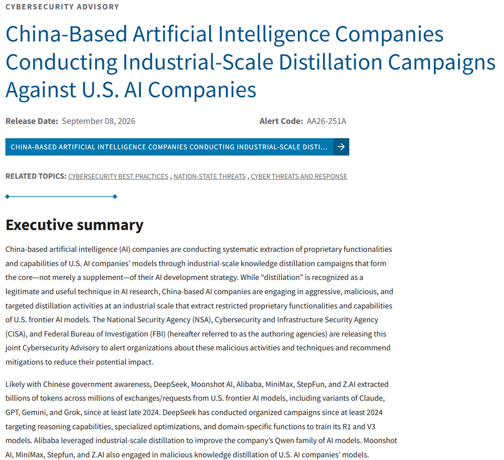

Distillation: training on a rival model’s outputs

- US agencies (Sep 8, 2026): 6 Chinese labs, “likely with Chinese government awareness” -> “billions of tokens” from US models
- Anthropic (Feb 2026): ~24,000 fraudulent accounts · > 16M exchanges w/ Claude

Govt attribution + company allegations, not court findings · Anthropic’s figures = its own

NSA, CISA and FBI, advisory AA26-251A, Sep 8, 2026; Anthropic, Feb 23, 2026

## Leak 4: what does documented espionage look like?

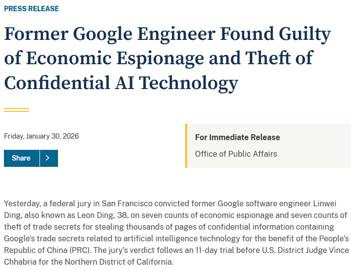

Jan 29, 2026: jury convicts ex-Google engineer Linwei Ding: economic espionage + AI trade-secret theft

- Aug 2026: judge vacates espionage counts · trade-secret convictions stand
- Sentence: just under 1 yr in prison

One case · judge: insufficient evidence he meant to benefit PRC govt

DOJ, Jan 30, 2026; KQED, Sep 1, 2026

## Leak 5: what if you buy before the door shuts?

$16B+ H20 orders

> $16B Nvidia H20 orders, 3 Chinese firms (reported, Apr 2025)

Huawei stockpiled chip dies + high-bandwidth memory around Dec 2024 controls

Order figure first reported by *The Information*.

IFP, Apr 15, 2025

## Do controls backfire?

| Controls spur the target | Controls slow the target |
| --- | --- |
| Hit firms “respond disproportionately by investing in research and development” (Clayton et al. 2025) | China’s chip-equipment localization “predated any modern effort to impose meaningful export controls” (Allen 2024) |
|  | Controls “can at best slow and disrupt Chinese efforts, not stop them” (Allen 2025) |

Clayton et al.: NBER working paper.

Clayton, Coppola, Maggiori and Schreger, NBER, Jul 2025; Allen, CSIS, Nov 26, 2024 and Mar 7, 2025

## Who pays for the controls?

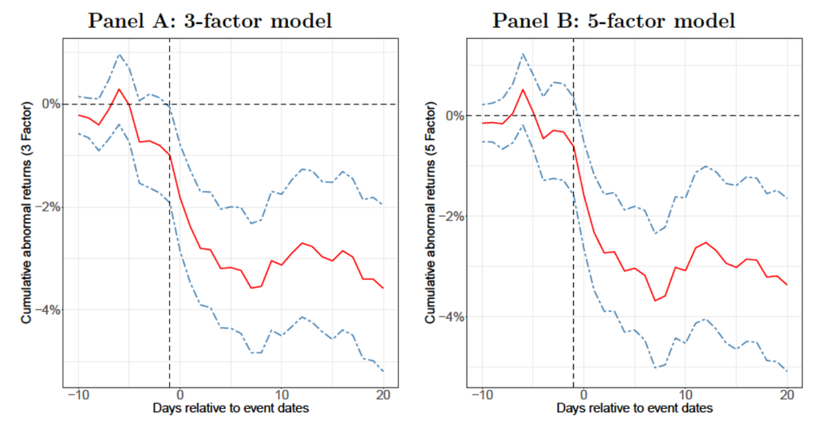

US suppliers: −$130B market value after Entity List additions, 2010–22

“In China, we have now dropped to zero.” “…already largely backfired.” Jensen Huang, Nvidia, May 2026

Allies: Dutch licence rules widened (Sep 2024, Apr 2025); Nexperia dispute (Sep–Nov 2025)

NY Fed: Entity List additions 2010–22, not AI-chip rules · “zero” = Nvidia’s share of China’s AI-accelerator market

Crosignani et al., NY Fed Staff Report 1096, 2025; Tom’s Hardware, May 3, 2026; Government of the Netherlands

## What can Beijing squeeze?

Export curbs: gallium, germanium, antimony -> US (Dec 2024) · rare earths (Apr + Oct 2025)

Antitrust: preliminary finding vs Nvidia (Sep 2025)

Customs: H200s “not permitted to enter China” (Jan 2026) · ~600,000 reportedly waiting in Hong Kong (Nov 5, 2026)

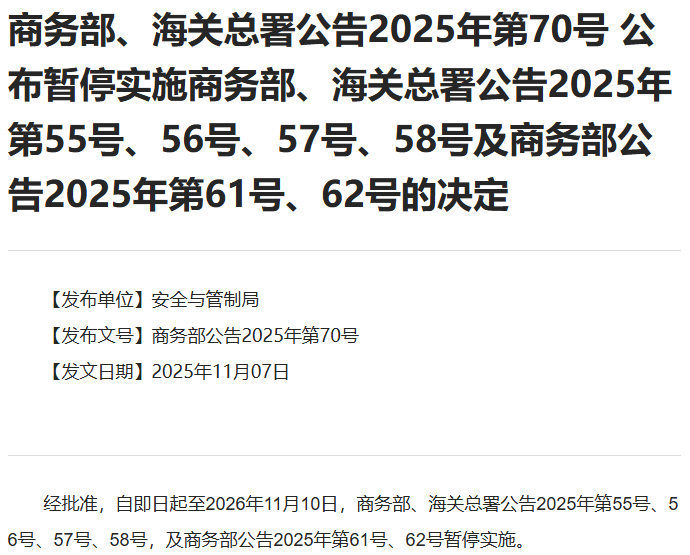

Customs + Hong Kong reports: anonymous sources (Reuters) · unconfirmed by Nvidia or Beijing

MOFCOM announcements; CNBC, Sep 15, 2025; Reuters, Jan 15 and Nov 5, 2026

## Does every chokepoint invite a counter-chokepoint?

“Each side’s attempt to become safer makes others feel less secure, driving further escalation.” Farrell, Newman and Tan

- Cold War: control regimes expand -> “weakening enforcement and encouraging defection” (Lind and Mastanduno)

Who writes the technical standards?

**Nov 10**  
Tomorrow: China’s rare-earth curb suspension expires · wider truce -> Jan 10, 2027

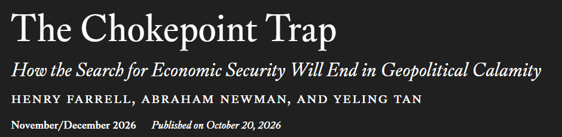

No MOFCOM extension of Nov 10 date, as of Nov 7, 2026

*Foreign Affairs*, Nov/Dec 2026; *Texas National Security Review*, Sep 2025; MOFCOM Announcement 2025 No. 70; MOFCOM readout, Sep 28, 2026

## What should you take from today?

1. Security dilemma -> race framing · stakes depend on prize: first to AGI vs diffusion marathon
2. US leads: compute, chips, money, frontier · China: open models, robots, power -> winner depends on race
3. Chips = US chokepoint, but leaky: smuggling, remote access, distillation, espionage, stockpiling · China has chokepoints too

Back to the start: ahead at what?

## See you next class

Implementation Milestone · Sun, Nov 15, 11:59 p.m. · 800–1,000 words

Wednesday, Nov 11: Agentic AI: From Chatbots to Agents · Yiqing Xu

Next Monday, Nov 16: AI Sovereignty